# Gapminder analysis

Gb

2017-09-19

```r
library(gapminder)
```

```r
library(tidyverse)
class(gapminder)
```

```
## [1] "tbl_df"     "tbl"        "data.frame"
```

#### Questions about gapminder

##### gapminder is a data.frame

##### gapminder is a tibble

```r
str(gapminder)
```

```
## Classes 'tbl_df', 'tbl' and 'data.frame':    1704 obs. of  6 variables:
##  $ country  : Factor w/ 142 levels "Afghanistan",..: 1 1 1 1 1 1 1 1 1 1 ...
##  $ continent: Factor w/ 5 levels "Africa","Americas",..: 3 3 3 3 3 3 3 3 3 3 ...
##  $ year     : int  1952 1957 1962 1967 1972 1977 1982 1987 1992 1997 ...
##  $ lifeExp  : num  28.8 30.3 32 34 36.1 ...
##  $ pop      : int  8425333 9240934 10267083 11537966 13079460 14880372 12881816 13867957 16317921 22227415 ...
##  $ gdpPercap: num  779 821 853 836 740 ...
```

##### gapminder has 6 variables/columns

##### gapminder has 1704 rows/observations

##### facts about extent and size can be gather in more than one way. If you want to have a quick glimpse about the dataset than str() is a useful function. If you want to know specifically about columns, names of variables or look at the top of the bottom of the dataset than fuctions like ncol(), names(), length(), dim(), nrow(), head() or tail() could be useful

##### Data type of variables: country and continent are factors, year and population are integers and lifeExp and gdpPercap are numerical

#### Exploring individual variables

##### Categorical data= continent, quantitative data= gdpPercapita

##### Values and range of each variable explored using summary, table, barplots and histograms

```r
summary(gapminder$continent)
```

```
##   Africa Americas     Asia   Europe  Oceania
##      624      300      396      360       24
```

```r
table(gapminder$continent)
```

```
##
##   Africa Americas     Asia   Europe  Oceania
##      624      300      396      360       24
```

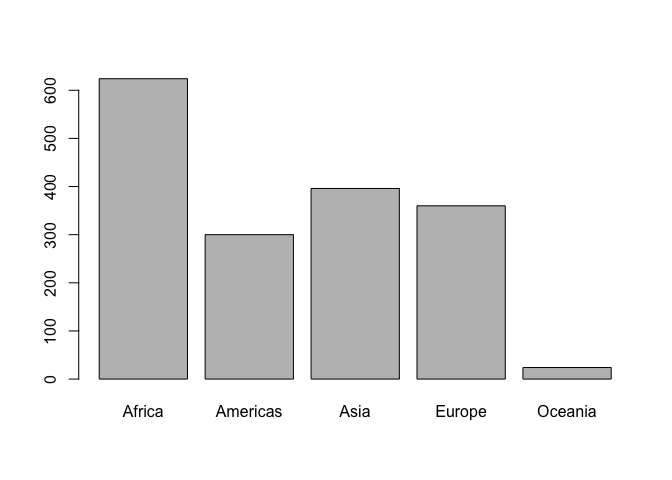

```r
barplot(table(gapminder$continent))
```

```r
summary(gapminder$lifeExp)
```

```
##    Min. 1st Qu.  Median    Mean 3rd Qu.    Max.
##   23.60   48.20   60.71   59.47   70.85   82.60
```

```r
table(gapminder$lifeExp)
```

[output not shown]

[output cut: 354 more lines]

[output not shown]

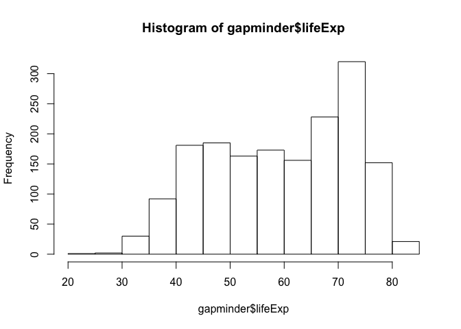

```r
hist(gapminder$lifeExp)
```

#### Explore various plot types

##### Scatterplot of two quantitative variables (lifeExp and gdpPerCapita)

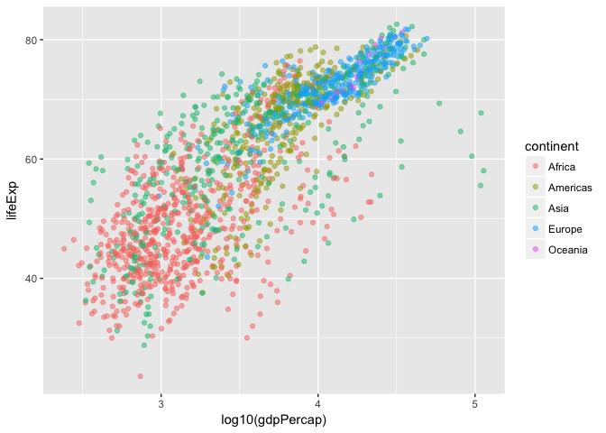

```r
p <- ggplot(gapminder, aes(x=log10(gdpPercap), y=lifeExp))
p + geom_point (aes(colour=continent), alpha=0.5)
```

#### Plot of one quantitative variable

##### Densityplot of gdpPercap

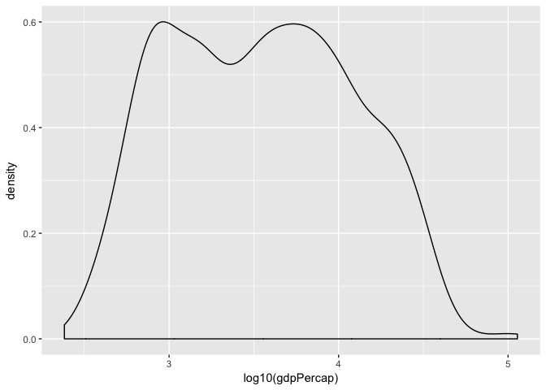

```r
ggplot (gapminder, aes(x=log10(gdpPercap))) + geom_density()
```

##### add colours for different continents

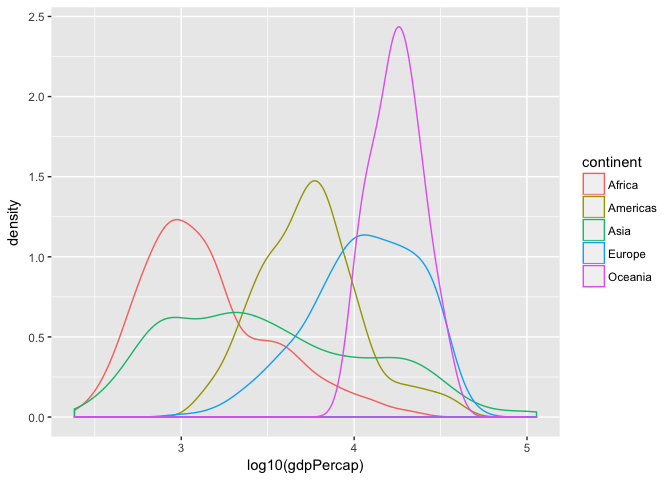

```r
ggplot (gapminder, aes(x=log10(gdpPercap), colour=continent)) + geom_density()
```

##### Removed Oceania because it had very few datapoints

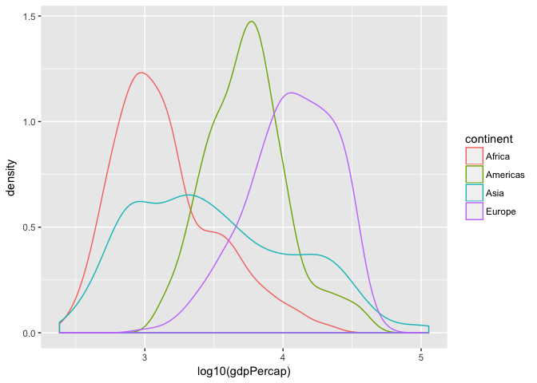

```r
ggplot (subset(gapminder, continent!= "Oceania"), aes(x=log10(gdpPercap), colour=continent)) + geom_density()
```

##### Experimented with facet wrap and transparency as demonstrated in Jenny’s [ggplot tutorial](https://github.com/jennybc/ggplot2-tutorial/blob/master/gapminder-ggplot2-univariate-quantitative.md)

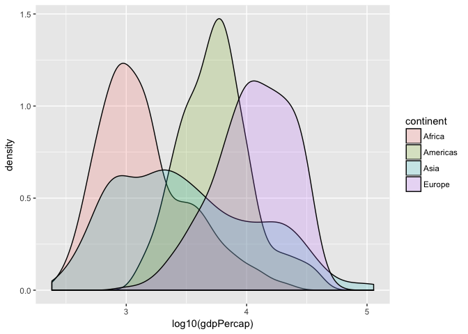

```r
ggplot (subset(gapminder, continent!= "Oceania"), aes(x=log10(gdpPercap), fill=continent)) + geom_density(alpha=0.2)
```

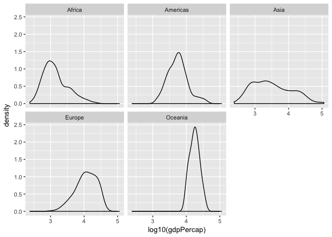

```r
ggplot(gapminder, aes(x=log10(gdpPercap))) + geom_density() + facet_wrap(~ continent)
```

#### Plot one quantitative variable and one categorical

##### Boxplot of European countries’ gdpPercap by year

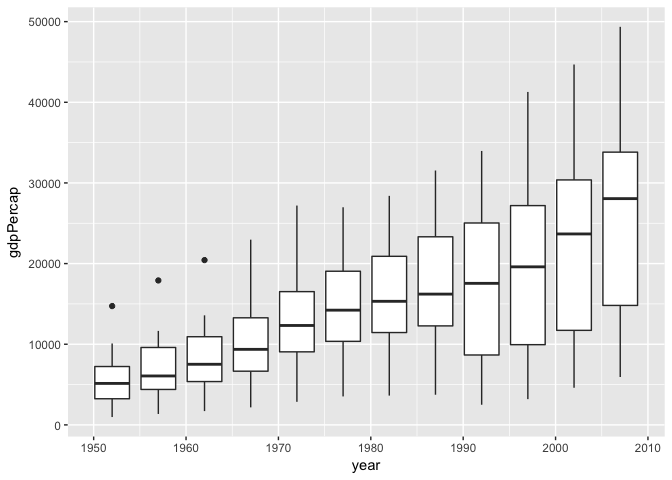

```r
ggplot (subset(gapminder, continent == "Europe"), aes(x=year, y=gdpPercap)) + geom_boxplot(aes(group=year))
```

#### Scatterplot of Canada and the Ireland using piping together of filter and select

##### To keep my code tidy, I assigned my piped data to the variable z. I filtered by Canada and Ireland and selected the data on the country name, year and gdpPercap. I then tested for z to make sure all the data I wanted was there

```r
z= gapminder %>%
  filter(country %in% c("Canada", "Ireland")) %>%
  select (country, year, gdpPercap)
```

```r
z
```

```
## # A tibble: 24 x 3
##    country  year gdpPercap
##     <fctr> <int>     <dbl>
##  1  Canada  1952  11367.16
##  2  Canada  1957  12489.95
##  3  Canada  1962  13462.49
##  4  Canada  1967  16076.59
##  5  Canada  1972  18970.57
##  6  Canada  1977  22090.88
##  7  Canada  1982  22898.79
##  8  Canada  1987  26626.52
##  9  Canada  1992  26342.88
## 10  Canada  1997  28954.93
## # ... with 14 more rows
```

##### I assigned the z variable as my dataset when using ggplot and examined the change of the two countries’ gdpPercap by year. I assigned the variable p as my ggplot x and y data. To make it look more informative I assigned different colours for the two countries and included a line of best fit. I used the geom_point function to add coloured points and the geom_smooth to add a line of best fit (with no error bars), and also utilized the resources from Jenny’s [ggplot tutorial](https://github.com/jennybc/ggplot2-tutorial/blob/master/gapminder-ggplot2-scatterplot.md)

```r
p <- ggplot (z, aes(x=year, y=gdpPercap))
```

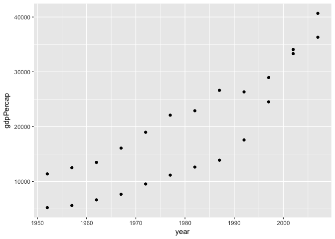

```r
p+ geom_point()
```

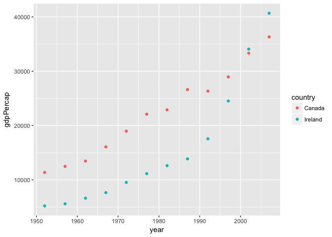

```r
p + geom_point(aes(colour = country))
```

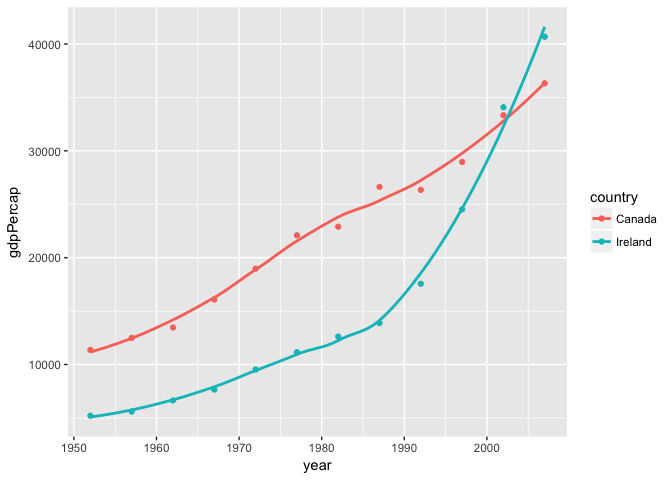

```r
p + aes(colour = country) + geom_point() + geom_smooth(se= FALSE)
```

### But I want to do more!

##### Afghanistan and Rwanda exercise

```r
filter(gapminder, country == c("Rwanda", "Afghanistan"))
```

```
## # A tibble: 12 x 6
##        country continent  year lifeExp      pop gdpPercap
##         <fctr>    <fctr> <int>   <dbl>    <int>     <dbl>
##  1 Afghanistan      Asia  1957  30.332  9240934  820.8530
##  2 Afghanistan      Asia  1967  34.020 11537966  836.1971
##  3 Afghanistan      Asia  1977  38.438 14880372  786.1134
##  4 Afghanistan      Asia  1987  40.822 13867957  852.3959
##  5 Afghanistan      Asia  1997  41.763 22227415  635.3414
##  6 Afghanistan      Asia  2007  43.828 31889923  974.5803
##  7      Rwanda    Africa  1952  40.000  2534927  493.3239
##  8      Rwanda    Africa  1962  43.000  3051242  597.4731
##  9      Rwanda    Africa  1972  44.600  3992121  590.5807
## 10      Rwanda    Africa  1982  46.218  5507565  881.5706
## 11      Rwanda    Africa  1992  23.599  7290203  737.0686
## 12      Rwanda    Africa  2002  43.413  7852401  785.6538
```

##### It appears the code is correct, but if you look closer there are five year intervals missing from both datasets eg. Afghanistan has data for 1957 but not 1962, or 1972 etc. The reason for this is that there are not using the “country” %in% “function which finds all instances in the datasets where the data includes Rwanada and Afghanistan. Using the filter function only for Afghanistan and Rwanda filters rows based on the country and ends up alternating between Rwanada and Afghanistan for each year. We can test this by using the same code but switching so Afghanistan is first.

```r
filter(gapminder, country == c("Afghanistan", "Rwanda"))
```

```
## # A tibble: 12 x 6
##        country continent  year lifeExp      pop gdpPercap
##         <fctr>    <fctr> <int>   <dbl>    <int>     <dbl>
##  1 Afghanistan      Asia  1952  28.801  8425333  779.4453
##  2 Afghanistan      Asia  1962  31.997 10267083  853.1007
##  3 Afghanistan      Asia  1972  36.088 13079460  739.9811
##  4 Afghanistan      Asia  1982  39.854 12881816  978.0114
##  5 Afghanistan      Asia  1992  41.674 16317921  649.3414
##  6 Afghanistan      Asia  2002  42.129 25268405  726.7341
##  7      Rwanda    Africa  1957  41.500  2822082  540.2894
##  8      Rwanda    Africa  1967  44.100  3451079  510.9637
##  9      Rwanda    Africa  1977  45.000  4657072  670.0806
## 10      Rwanda    Africa  1987  44.020  6349365  847.9912
## 11      Rwanda    Africa  1997  36.087  7212583  589.9445
## 12      Rwanda    Africa  2007  46.242  8860588  863.0885
```

##### Indeed we see that the same thing happens where the filter function alternates selecting for the two countries, this time starting with Afghanistan in 1952, then Rwanada 1957 etc. Using the %in% function as I mentioned above will retrieve all the data we need.

```r
filter(gapminder,country %in% c("Afghanistan", "Rwanda"))
```

```
## # A tibble: 24 x 6
##        country continent  year lifeExp      pop gdpPercap
##         <fctr>    <fctr> <int>   <dbl>    <int>     <dbl>
##  1 Afghanistan      Asia  1952  28.801  8425333  779.4453
##  2 Afghanistan      Asia  1957  30.332  9240934  820.8530
##  3 Afghanistan      Asia  1962  31.997 10267083  853.1007
##  4 Afghanistan      Asia  1967  34.020 11537966  836.1971
##  5 Afghanistan      Asia  1972  36.088 13079460  739.9811
##  6 Afghanistan      Asia  1977  38.438 14880372  786.1134
##  7 Afghanistan      Asia  1982  39.854 12881816  978.0114
##  8 Afghanistan      Asia  1987  40.822 13867957  852.3959
##  9 Afghanistan      Asia  1992  41.674 16317921  649.3414
## 10 Afghanistan      Asia  1997  41.763 22227415  635.3414
## # ... with 14 more rows
```

#### Utilizing more dplyr functions

##### To utilize and learn more about dplyr functions I asked the following question and tried to work backward to find the data: What country experienced the sharpest 5-year increase in population?

##### First I created a copy of gapminder so I could make changes to the tibble without effecting the data in the package

```r
edit_gap <- gapminder
```

```r
edit_gap
```

```
## # A tibble: 1,704 x 6
##        country continent  year lifeExp      pop gdpPercap
##         <fctr>    <fctr> <int>   <dbl>    <int>     <dbl>
##  1 Afghanistan      Asia  1952  28.801  8425333  779.4453
##  2 Afghanistan      Asia  1957  30.332  9240934  820.8530
##  3 Afghanistan      Asia  1962  31.997 10267083  853.1007
##  4 Afghanistan      Asia  1967  34.020 11537966  836.1971
##  5 Afghanistan      Asia  1972  36.088 13079460  739.9811
##  6 Afghanistan      Asia  1977  38.438 14880372  786.1134
##  7 Afghanistan      Asia  1982  39.854 12881816  978.0114
##  8 Afghanistan      Asia  1987  40.822 13867957  852.3959
##  9 Afghanistan      Asia  1992  41.674 16317921  649.3414
## 10 Afghanistan      Asia  1997  41.763 22227415  635.3414
## # ... with 1,694 more rows
```

##### Next I wanted select only the variables I am interested in using the group by function for continent and country. At each step I am assigning a new variable (s1, s2 etc) to make it easy to follow along

```r
s1<- edit_gap %>%
  select (country, year, continent, pop) %>%
  group_by(continent, country)
```

```r
s1
```

```
## # A tibble: 1,704 x 4
## # Groups:   continent, country [142]
##        country  year continent      pop
##         <fctr> <int>    <fctr>    <int>
##  1 Afghanistan  1952      Asia  8425333
##  2 Afghanistan  1957      Asia  9240934
##  3 Afghanistan  1962      Asia 10267083
##  4 Afghanistan  1967      Asia 11537966
##  5 Afghanistan  1972      Asia 13079460
##  6 Afghanistan  1977      Asia 14880372
##  7 Afghanistan  1982      Asia 12881816
##  8 Afghanistan  1987      Asia 13867957
##  9 Afghanistan  1992      Asia 16317921
## 10 Afghanistan  1997      Asia 22227415
## # ... with 1,694 more rows
```

##### Next I want to use mutate to make a new data point which will tell me how pop changed by year ((pop in year i)- (pop in year i - 1). This will mean that positive numbers will indicate that the population went up. I am using the lag function which finds the change based on the datapoint before the point in question (eg. x - (x-1))

```r
s2<- s1 %>%
  mutate(pop_delta = pop -lag(pop))
```

```r
s2
```

```
## # A tibble: 1,704 x 5
## # Groups:   continent, country [142]
##        country  year continent      pop pop_delta
##         <fctr> <int>    <fctr>    <int>     <int>
##  1 Afghanistan  1952      Asia  8425333        NA
##  2 Afghanistan  1957      Asia  9240934    815601
##  3 Afghanistan  1962      Asia 10267083   1026149
##  4 Afghanistan  1967      Asia 11537966   1270883
##  5 Afghanistan  1972      Asia 13079460   1541494
##  6 Afghanistan  1977      Asia 14880372   1800912
##  7 Afghanistan  1982      Asia 12881816  -1998556
##  8 Afghanistan  1987      Asia 13867957    986141
##  9 Afghanistan  1992      Asia 16317921   2449964
## 10 Afghanistan  1997      Asia 22227415   5909494
## # ... with 1,694 more rows
```

##### Next I want to retain the best pop change, which means the biggest value that is positive. For this I use the summarize function and the max function. To exclude any missing numbers from the analysis I am using “na.rm= TRUE”

```r
s3 <- s2 %>%
  summarize(best_pop_delta = max(pop_delta, na.rm = TRUE))
```

```r
s3
```

```
## # A tibble: 142 x 3
## # Groups:   continent [?]
##    continent                  country best_pop_delta
##       <fctr>                   <fctr>          <dbl>
##  1    Africa                  Algeria        3221203
##  2    Africa                   Angola        1554370
##  3    Africa                    Benin        1084409
##  4    Africa                 Botswana         193922
##  5    Africa             Burkina Faso        2074994
##  6    Africa                  Burundi        1369427
##  7    Africa                 Cameroon        1766305
##  8    Africa Central African Republic         431389
##  9    Africa                     Chad        1403068
## 10    Africa                  Comoros          96578
## # ... with 132 more rows
```

##### Arrange in descending order

```r
s3 %>%
  arrange (desc(best_pop_delta))
```

```
## # A tibble: 142 x 3
## # Groups:   continent [5]
##    continent          country best_pop_delta
##       <fctr>           <fctr>          <dbl>
##  1      Asia            China      107480000
##  2      Asia            India       87000000
##  3      Asia         Pakistan       17838690
##  4      Asia        Indonesia       16618000
##  5  Americas    United States       16017571
##  6    Africa          Nigeria       15129890
##  7      Asia       Bangladesh       14791549
##  8  Americas           Brazil       14648988
##  9    Africa Congo, Dem. Rep.        9226907
## 10    Africa         Ethiopia        9089029
## # ... with 132 more rows
```

##### From this table I can see that the highest population growths from the gapminder data set. The largest is China which grew over a 107M people in a span of five years. The top four are from Asia. If I wanted to see the highest pop growth by continent I would first use filter and max rank to select the top entry of each group, which is convieniently put together in the function top n. This lets you select for the top n rows and you assign the wt as being the newly created variable best_pop_delta. As we have already grouped by continent earlier it follows here.

```r
s4 <- s3 %>%
  top_n(1, wt = best_pop_delta) %>%
  arrange (desc(best_pop_delta))
```

```r
s4
```

```
## # A tibble: 5 x 3
## # Groups:   continent [5]
##   continent       country best_pop_delta
##      <fctr>        <fctr>          <dbl>
## 1      Asia         China      107480000
## 2  Americas United States       16017571
## 3    Africa       Nigeria       15129890
## 4    Europe        Turkey        5552537
## 5   Oceania     Australia        1304736
```

##### From this you can see the highest population increases in the other continents, with the smallest occuring in Australia which is in Oceania. In their best 5 year stretch, Australia added 1.3M to it’s population total.

##### I really enjoyed this exercise, a modified version of which is in the [dplyr functions in a single dataset](http://stat545.com/block010_dplyr-end-single-table.html#grand-finale) on the stats 545 website